# Feature selection and machine learning models

## 1. Overview

This is a case study of machine learning models (R programming) using credit default data. In this repository you can find also some solutions about data cleaning, data enginerring or some methods how present data at charts using R programming. In this project, I try to illustrate the complete workflow (I indicate the script where you can find more R programming details).

To solve the classification problem (customer is bad or good) I used some algorithms:

- Logistic Regression,
- Decision Trees,
- Bagging with Random Forests,
- Boosting with AdaBoost,
- **How start**

You can start with the `main.R` script.

### 1.1 Dataset description

Dataset used from **Kaggle Lending Club**. To import dataset it is needed to download a file *loan.csv* from this [website](https://www.kaggle.com/wendykan/lending-club-loan-data). This file contains loan data for all loans issued through the 2007-2015. The file is a matrix of about 890 thousand observations and 75 variables. To import data you can use `0a.importData.R`

Let’s check how the number of bad customers has changed over time.

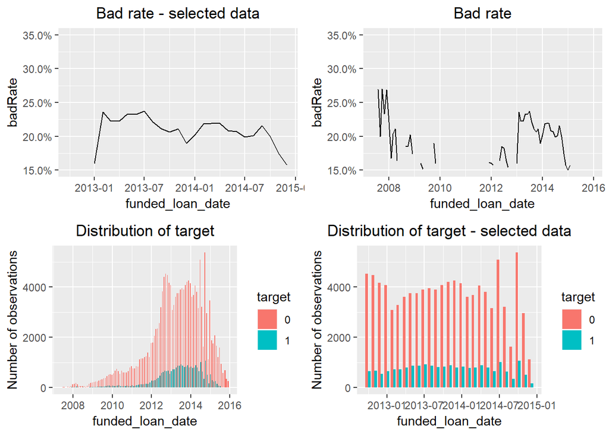

### 1.2 Cleaning data

### 1.3 Feature engineering

## 2. Models building

### 2.1 Logistic Regression

#### 2.2 Using Information value (IV) and weight of evidence (Woe)

- **Feature selecion using the Information value (IV) and the weight of evidence (Woe)**

Using measure *Information value* you can select important variables in a predictive model.

This measure helps to rank variables on the basis of their importance.

Information values for all variables from the *Lending Club dataset* are as follows:

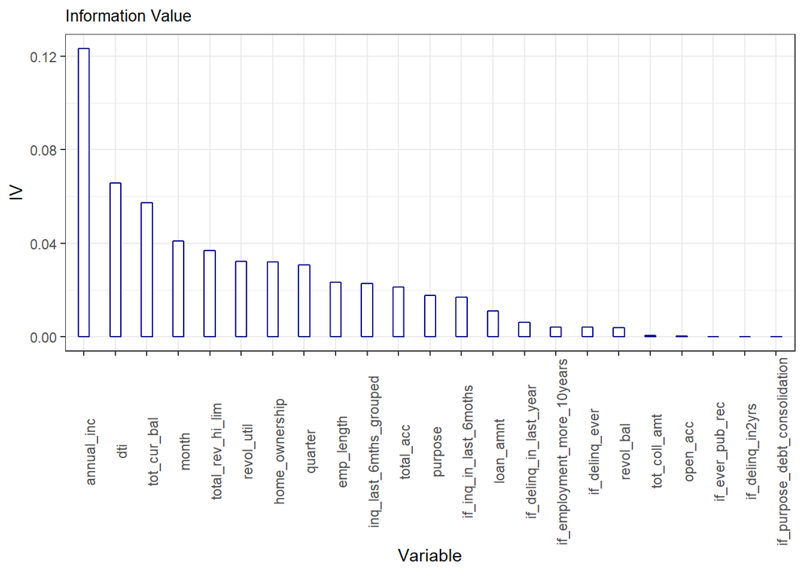

When information value is less than 0.02 means that it is not useful for prediction. For 11 variables from the dataset invormation value is greater than 0.02:

| Variable | IV | Is it a useful variable? |
| --- | --- | --- |
| annual_inc | 0.12327 | Yes |
| dti | 0.06565 | Yes |
| tot_cur_bal | 0.05729 | Yes |
| month | 0.04102 | Yes |
| total_rev_hi_lim | 0.03685 | Yes |
| revol_util | 0.03231 | Yes |
| home_ownership | 0.03207 | Yes |
| quarter | 0.03065 | Yes |
| emp_length | 0.02321 | Yes |
| inq_last_6mths_grouped | 0.02291 | Yes |
| total_acc | 0.02127 | Yes |
| purpose | 0.01766 | No |
| if_inq_in_last_6moths | 0.01691 | No |
| loan_amnt | 0.01101 | No |
| if_delinq_in_last_year | 0.00622 | No |
| if_employment_more_10years | 0.00409 | No |
| if_delinq_ever | 0.00405 | No |
| revol_bal | 0.00382 | No |
| tot_coll_amt | 0.00066 | No |
| open_acc | 0.00024 | No |
| if_ever_pub_rec | 0.00003 | No |
| if_delinq_in2yrs | 0.00001 | No |
| if_purpose_debt_consolidation | 0.00000 | No |

The weight of evidence describes as a measure of the separation of good and bad borrowers. Bad borrowers are customers who defaulted on a loan. Instead of good borrowers are customers who paid back a loan. Analyzing results from these *Woe plots* It is important to remember that:

- The WOE should be monotonic i.e. either growing or decreasing with the bins,
- Woe can handle missing values as missing values can be binned separately. It is natural that can be Woe value for bin ‘NA’ of a variable.

To read more about terminology of *IV* and *Woe* click [here](http://ucanalytics.com/blogs/information-value-and-weight-of-evidencebanking-case/). Here some plots about Woe for each independent variable:

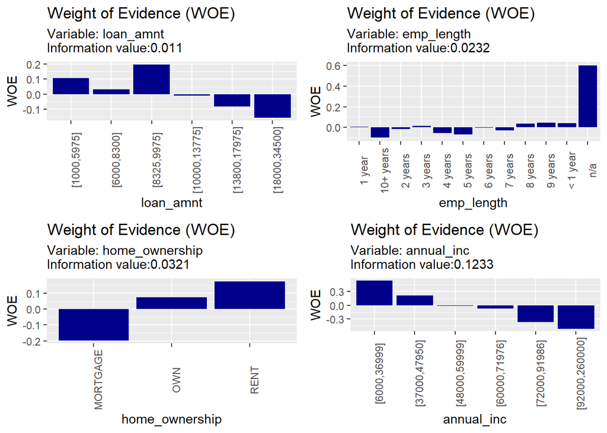

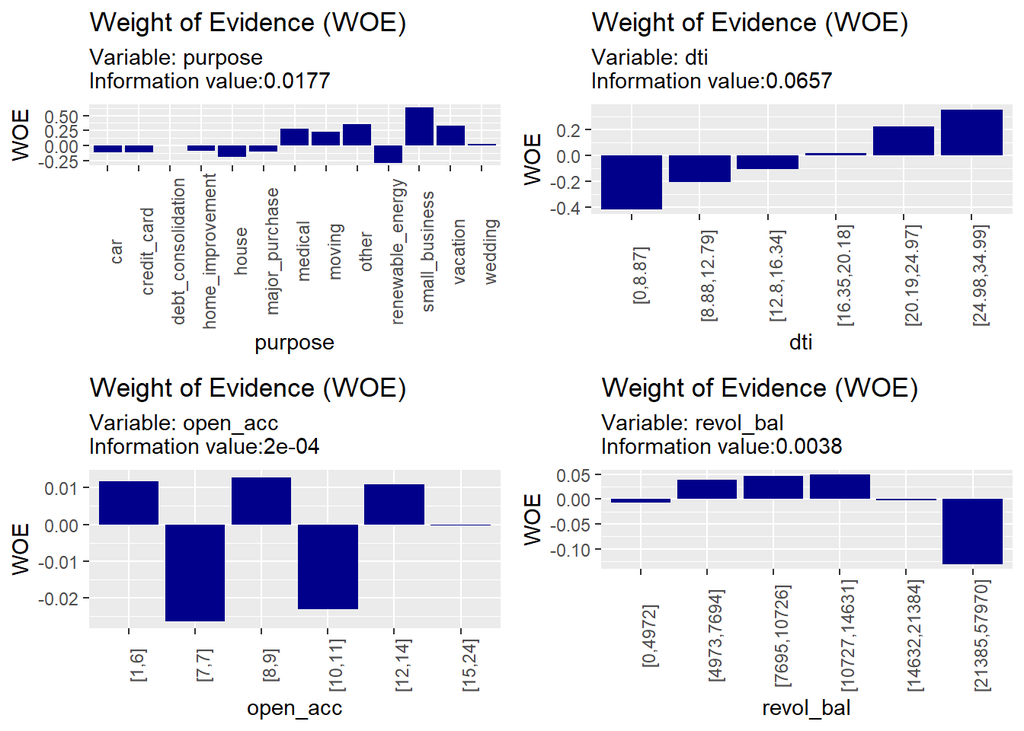

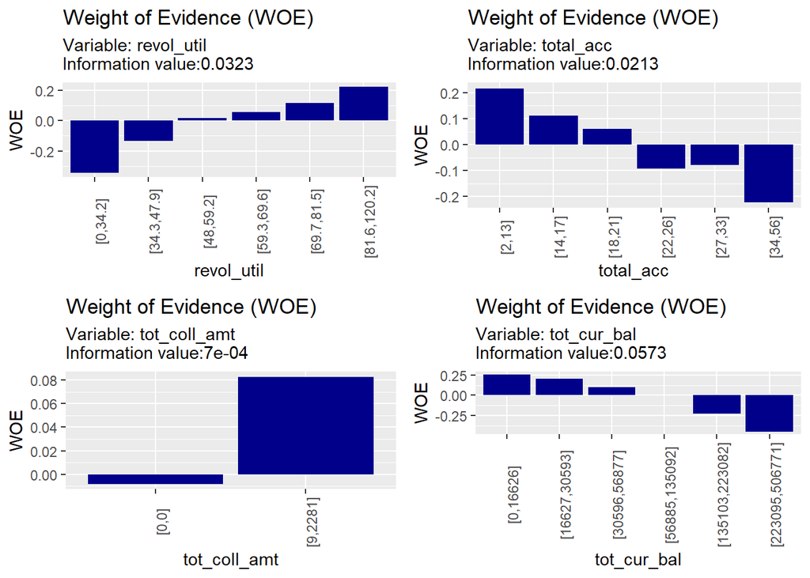

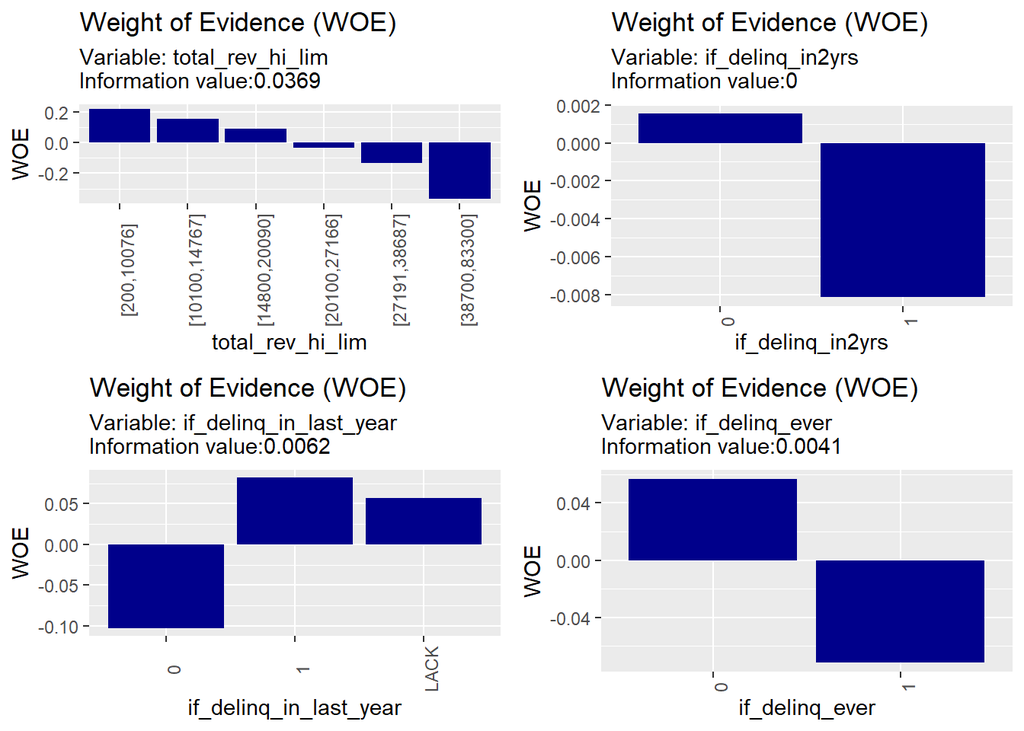

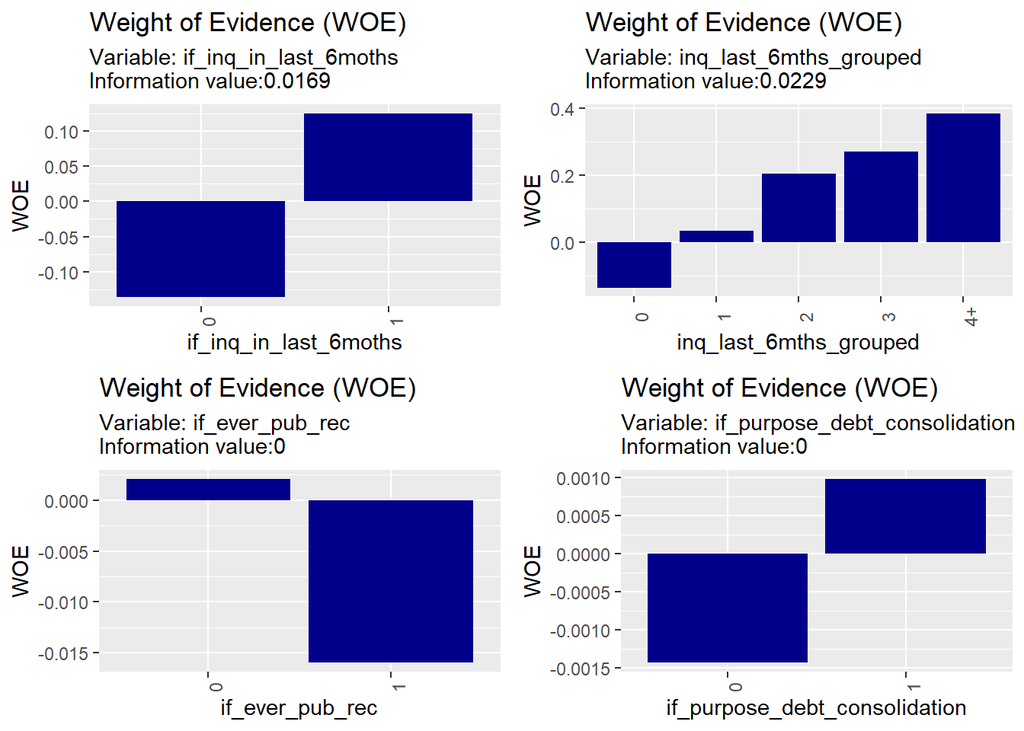

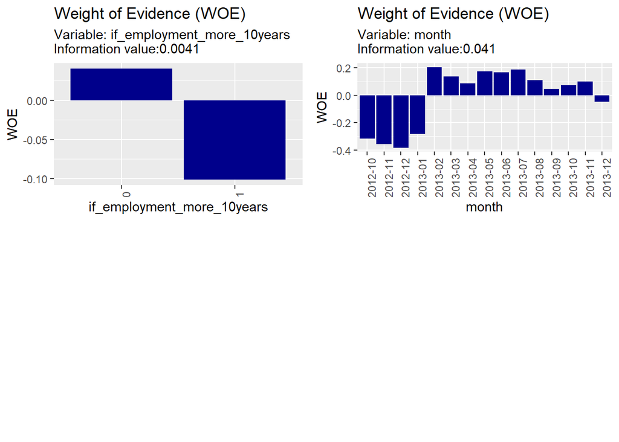

We can choose the right prospective variables to build a logistic regression model when we use information about measure IV and Woe (is monotonic or not for a variable). These variables fulfill the mentioned conditions:

```r
listOfSeletedVariables$continuous
```

```
## [1] "annual_inc"       "dti"              "tot_cur_bal"
## [4] "total_rev_hi_lim" "revol_util"       "total_acc"
```

```r
listOfSeletedVariables$discrete
```

```
## [1] "home_ownership"         "inq_last_6mths_grouped"
```

Lets see how *IV* measure changes over time. How strong this measure is different over time ? There are times in which a decrease in value *IV* is noticeable. It can be seen that the decline usually occurs from 2012 Q4. Greater *IV* stabilization has been visible since 2013 Q2.

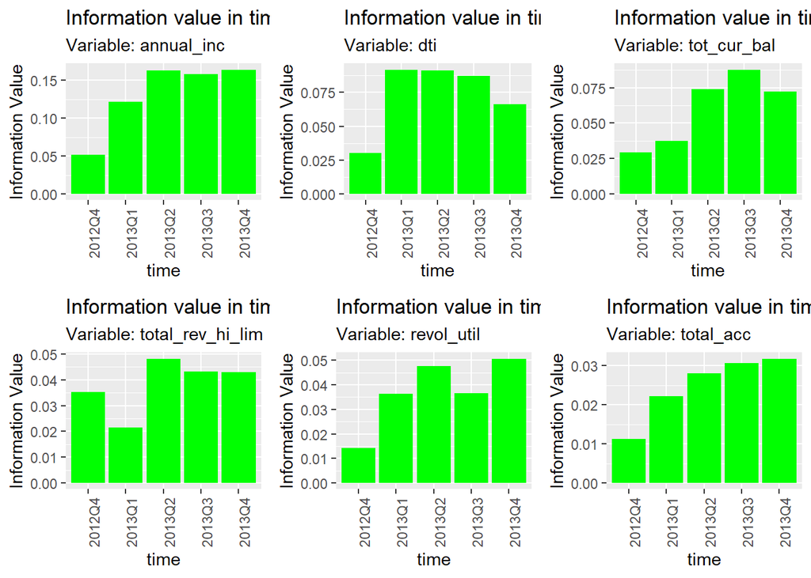

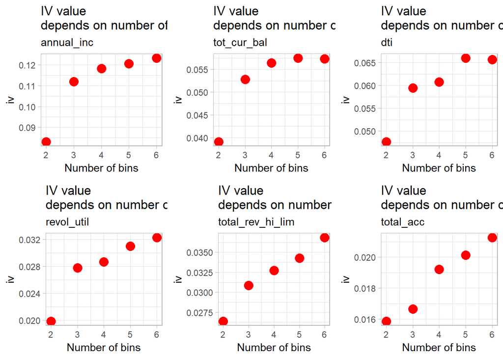

- **Coding selected variables using the value of the weight of evidence (Woe)**

Weight of evidence (WOE) coding of a nominal or discrete variable is widely used when preparing predictors for usage in binary logistic regression models. To build logistic regression model we can use Woe information. Here the example for *tot_cur_bal* variable and the results of coding.

| tot_cur_bal | N | Percent | WOE | IV |
| --- | --- | --- | --- | --- |
| [0,19168] | 7692 | 0.1999688 | 0.26431181 | 0.01520702 |
| [19169,38034] | 7693 | 0.1999948 | 0.16688387 | 0.02108687 |
| [38037,98870] | 7694 | 0.2000208 | 0.02034923 | 0.02117025 |
| [98900,203179] | 7693 | 0.1999948 | -0.10439266 | 0.02327538 |
| [203191,506771] | 7694 | 0.2000208 | -0.44622790 | 0.05750095 |

|  | loan_amnt | emp_length | home_ownership | annual_inc | purpose | dti | open_acc | revol_bal | revol_util | total_acc | tot_coll_amt | tot_cur_bal | total_rev_hi_lim | target | if_delinq_in2yrs | if_delinq_in_last_year | if_delinq_ever | if_inq_in_last_6moths | inq_last_6mths_grouped | if_ever_pub_rec | if_purpose_debt_consolidation | if_employment_more_10years | annual_inc_cut | annual_inc_woe | dti_cut | dti_woe | tot_cur_bal_cut | tot_cur_bal_woe | total_rev_hi_lim_cut | … |
| --- | --- | --- | --- | --- | --- | --- | --- | --- | --- | --- | --- | --- | --- | --- | --- | --- | --- | --- | --- | --- | --- | --- | --- | --- | --- | --- | --- | --- | --- | --- |
| 3 | 10000 | 10+ years | MORTGAGE | 41000 | debt_consolidation | 25.79 | 10 | 12409 | 65.0 | 16 | 0 | 50865 | 19100 | 0 | 0 | LACK | 0 | 1 | 1 | 1 | 1 | 1 | (37000,48000] | 0.21959196570494 | (18.58, Inf] | 0.163408255925627 | (38037,98900] | 0.0203492332593512 | (14800,20100] | … |
| 4 | 20000 | 10+ years | MORTGAGE | 80000 | debt_consolidation | 16.70 | 10 | 12948 | 45.0 | 26 | 0 | 16852 | 28800 | 0 | 1 | 1 | 1 | 1 | 1 | 1 | 1 | 1 | (72000, Inf] | -0.370477302575248 | (14.18,18.58] | -0.103895936590512 | [-Inf,19169] | 0.26431180508992 | (27191, Inf] | … |
| 5 | 16000 | < 1 year | MORTGAGE | 112000 | debt_consolidation | 7.39 | 12 | 6868 | 10.3 | 19 | 0 | 369614 | 66800 | 0 | 0 | LACK | 0 | 1 | 1 | 0 | 1 | 0 | (72000, Inf] | -0.370477302575248 | [-Inf,9.75] | -0.390159503920897 | (98900, Inf] | -0.104392662264289 | (27191, Inf] | … |
| 6 | 6000 | 8 years | RENT | 115000 | debt_consolidation | 7.37 | 12 | 7037 | 40.9 | 26 | 0 | 48236 | 17200 | 0 | 0 | LACK | 0 | 1 | 1 | 0 | 1 | 0 | (72000, Inf] | -0.370477302575248 | [-Inf,9.75] | -0.390159503920897 | (38037,98900] | 0.0203492332593512 | (14800,20100] | … |
| 7 | 6000 | 1 year | MORTGAGE | 70000 | credit_card | 25.14 | 20 | 27233 | 64.2 | 37 | 0 | 215466 | 42400 | 0 | 0 | LACK | 0 | 1 | 2 | 0 | 0 | 0 | (60000,72000] | -0.0724523966108571 | (18.58, Inf] | 0.163408255925627 | (98900, Inf] | -0.104392662264289 | (27191, Inf] | … |

- **Correlations between independent variables**

Corrplot:

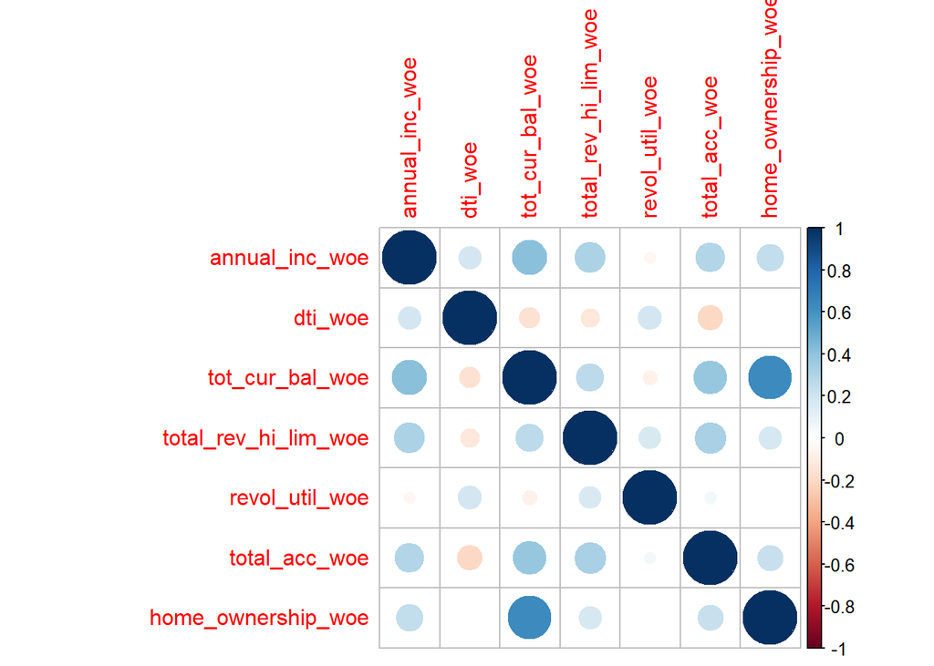

Correlation matrix:

|  | annual_inc_woe | dti_woe | tot_cur_bal_woe | total_rev_hi_lim_woe | revol_util_woe | total_acc_woe | home_ownership_woe |
| --- | --- | --- | --- | --- | --- | --- | --- |
| annual_inc_woe | 1.000 | 0.183 | 0.418 | 0.315 | -0.045 | 0.295 | 0.246 |
| dti_woe | 0.183 | 1.000 | -0.153 | -0.123 | 0.188 | -0.209 | 0.002 |
| tot_cur_bal_woe | 0.418 | -0.153 | 1.000 | 0.265 | -0.071 | 0.384 | 0.639 |
| total_rev_hi_lim_woe | 0.315 | -0.123 | 0.265 | 1.000 | 0.169 | 0.329 | 0.175 |
| revol_util_woe | -0.045 | 0.188 | -0.071 | 0.169 | 1.000 | 0.050 | -0.005 |
| total_acc_woe | 0.295 | -0.209 | 0.384 | 0.329 | 0.050 | 1.000 | 0.226 |
| home_ownership_woe | 0.246 | 0.002 | 0.639 | 0.175 | -0.005 | 0.226 | 1.000 |

#### 2.2 Build logistic regression models

The first logistic regression model used all the choosen independent variables (annual_inc_woe, dti_woe, tot_cur_bal_woe, total_rev_hi_lim_woe, revol_util_woe, total_acc_woe, home_ownership_woe) Let’s name it model_lr_woe. Summary of the model is as below:

```r
model_lr_woe <- glm(target~annual_inc_woe+dti_woe+tot_cur_bal_woe+total_rev_hi_lim_woe+revol_util_woe+total_acc_woe+home_ownership_woe,
                    data = dataSetWithVariablesCodedWoe,
                    family = binomial(link = "logit"))
summary(model_lr_woe)
```

```
##
## Call:
## glm(formula = target ~ annual_inc_woe + dti_woe + tot_cur_bal_woe +
##     total_rev_hi_lim_woe + revol_util_woe + total_acc_woe + home_ownership_woe,
##     family = binomial(link = "logit"), data = dataSetWithVariablesCodedWoe)
##
## Deviance Residuals:
##     Min       1Q   Median       3Q      Max
## -0.9521  -0.6502  -0.5487  -0.4415   2.3951
##
## Coefficients:
##                      Estimate Std. Error z value Pr(>|z|)
## (Intercept)          -1.60990    0.01612 -99.842  < 2e-16 ***
## annual_inc_woe        0.73640    0.05207  14.143  < 2e-16 ***
## dti_woe               1.04081    0.07688  13.539  < 2e-16 ***
## tot_cur_bal_woe       0.69083    0.13915   4.965 6.88e-07 ***
## total_rev_hi_lim_woe  0.43754    0.11610   3.769 0.000164 ***
## revol_util_woe        0.93136    0.09386   9.922  < 2e-16 ***
## total_acc_woe         0.28336    0.13059   2.170 0.030017 *
## home_ownership_woe    0.22203    0.10057   2.208 0.027270 *
## ---
## Signif. codes:  0 '***' 0.001 '**' 0.01 '*' 0.05 '.' 0.1 ' ' 1
##
## (Dispersion parameter for binomial family taken to be 1)
##
##     Null deviance: 35100  on 38465  degrees of freedom
## Residual deviance: 33994  on 38458  degrees of freedom
## AIC: 34010
##
## Number of Fisher Scoring iterations: 4
```

I think it still exists a better way to achieve more satisfying classification results. Maybe it depends on the time samples or the definition of the target. Maybe more work is needed at creating better new features from an existing dataset.